output: html_document Author: “Deepti Tiwari” —

## Forecasting

### Store-*233779* for Soups-*Campbells*

Aligining with the business objective of inventory management for the next month, forecasting goal is to predict the number of units to be sold in next four weeks i.e Week= 53, 54, 55 and 56. From the main data set **soup** we aggregated the *units* on weekly basis for store-233779(basis of IRI_Key). This time series is then used through out this analysis.

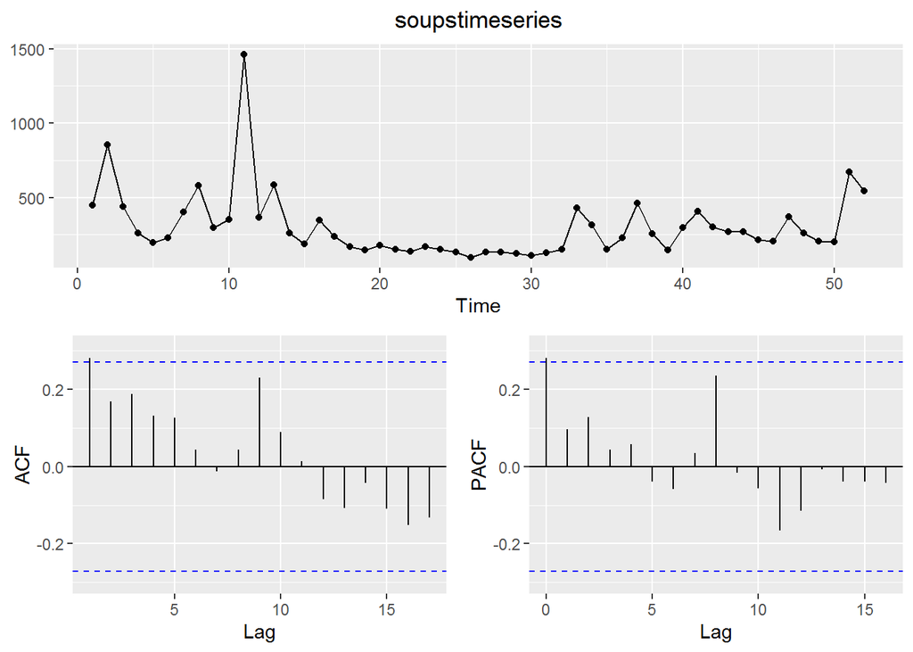

```r
library(forecast)


soups <- read.csv("Campbells_233779_data.csv")
soupstimeseries <- ts(soups)

# findfrequency(soupstimeseries)

ggtsdisplay(soupstimeseries)
```

Since this series contains data for 52 weeks hence cycle can not be detected, following plot gives better insight on seasonality.

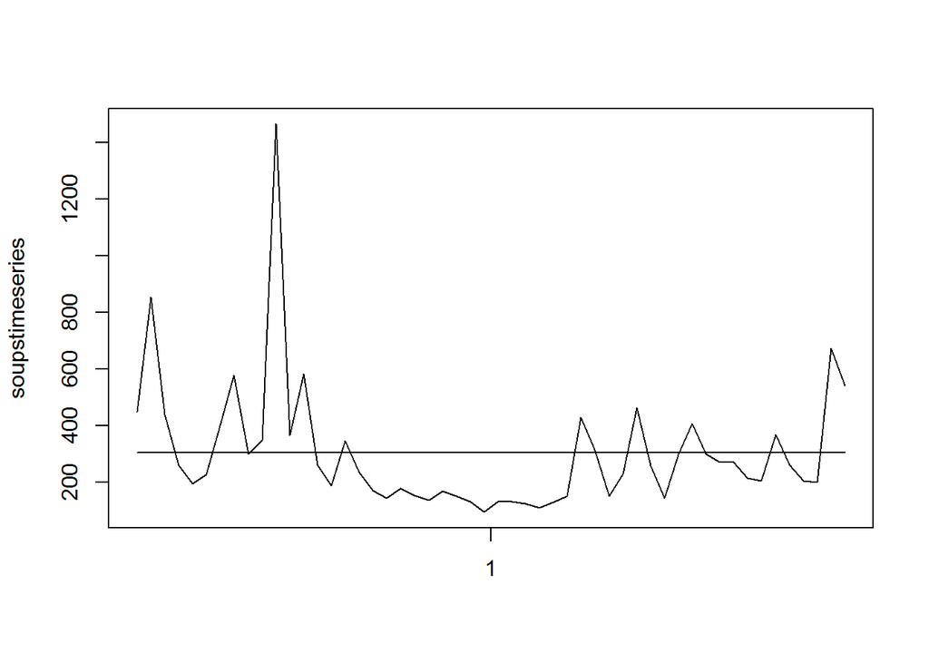

```r
monthplot(soupstimeseries)
```

From above plot it is clear there is no seasonality in this series.

Before proceeding to fit different models on this series, we forecasted on basis of **naive** and **mean** method.

[figure not shown]

```r
soupfit1 <- meanf(soupstimeseries, h = 4)
soupfit2 <- naive(soupstimeseries, h = 4)


plot(soupfit1, plot.conf = FALSE, main = "Forecasts for quarterly beer production")
lines(soupfit2$mean, col = 2)

lines(soupstimeseries)
legend("topright", lty = 1, col = c(1, 2), legend = c("Mean method", "Naive method"))
```

Following are the results of accuracy for these two methods.

```r
print("Accuracy of mean method")
```

```
## [1] "Accuracy of mean method"
```

```r
accuracy(soupfit1)
```

```
##              ME     RMSE      MAE       MPE     MAPE      MASE      ACF1
## Training set  0 225.8804 148.4904 -37.75052 59.93241 0.9660683 0.2813345
```

```r
print("Accuracy of naive method")
```

```
## [1] "Accuracy of naive method"
```

```r
accuracy(soupfit2)
```

```
##                    ME     RMSE      MAE       MPE     MAPE MASE       ACF1
## Training set 1.823529 270.6552 153.7059 -13.66429 42.98812    1 -0.4543271
```

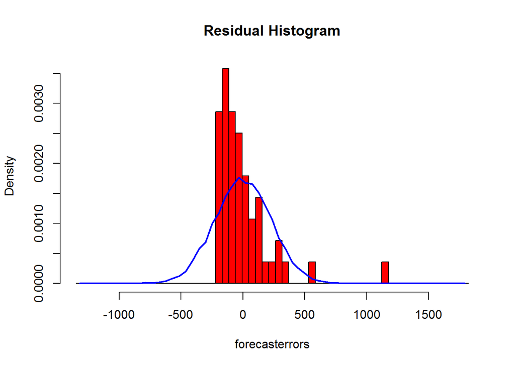

```r
res1 <- residuals(soupfit1)
plotForecastErrors(res1)
```

As trend is not clearly visible in this time series, we will fit different models and on basis of accuracy measures and residual analysis we will decide the best model to forecast.

Before running the model we have partitioned the series in **training set** with first 48 weeks and remaining weeks are kept in **validation set** as our forecast horizon is four weeks.

```r
souptraining <- ts(soupstimeseries[c(1:48), ])
soupvalidation <- ts(soupstimeseries[c(49:52), ])
```

### Starting with regression models:

1. **Linear Regression Model**

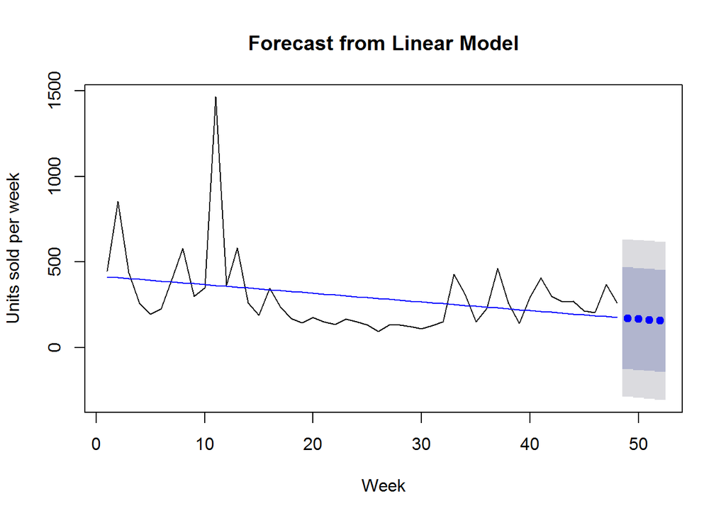

```r
soup.fit3 <- tslm(souptraining ~ trend)
f3 <- forecast(soup.fit3, h = 4, level = c(80, 95))
plot(f3, ylab = "Units sold per week", xlab = "Week", main = "Forecast from Linear Model")
lines(fitted(soup.fit3), col = "blue")
```

```r
accuracy(f3)
```

```
##                         ME     RMSE      MAE       MPE     MAPE      MASE
## Training set -7.696534e-15 214.1297 141.6938 -33.54429 58.92074 0.9286862
##                   ACF1
## Training set 0.2052765
```

This model gave us RMSE of **214.12** and MAPE **58.92%**, we further analyse the residuals of this model.

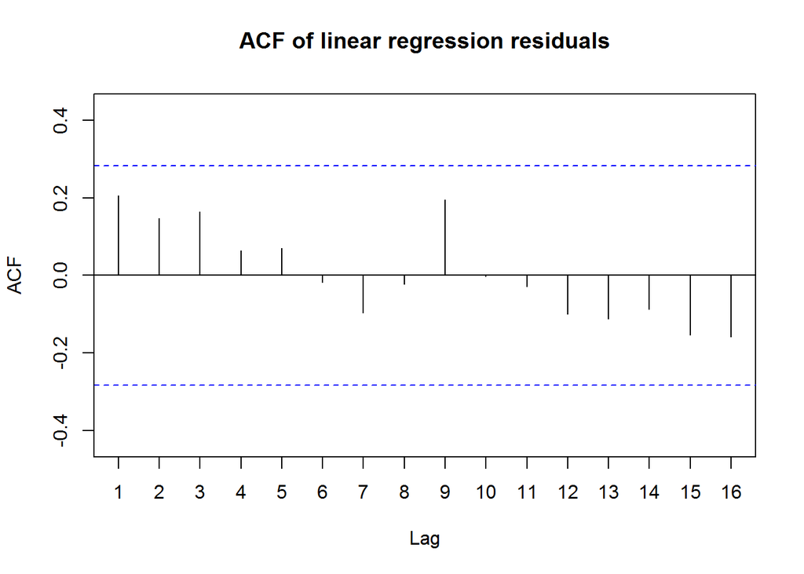

```r
res3 <- residuals(soup.fit3)
# plot(res3, main='Residuals from linear regression method',
# ylab='residuals', xlab='Week') abline(0,0,col='gray60')
Acf(res3, main = "ACF of linear regression residuals")
```

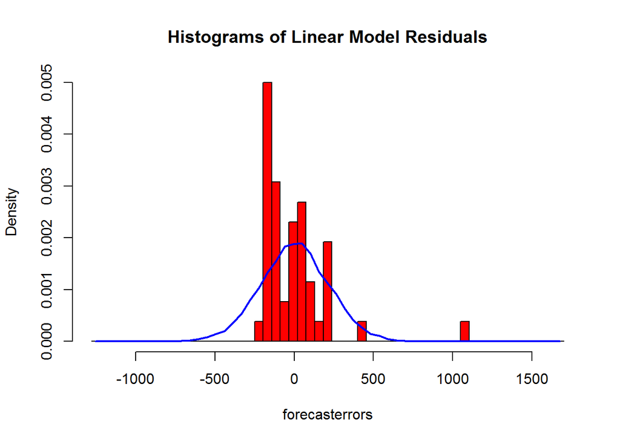

```r
plotForecastErrors(res3, "Histograms of Linear Model Residuals")
```

From ACF plot it is visible that there is no autocorelation but from residuals histogram we can see that mean of residuals are somewhat close to *zero* and residuals are not normally distributed. However we can not conclude this as the best model to forecats without running other models.

2. **Quadratic Regression Model**

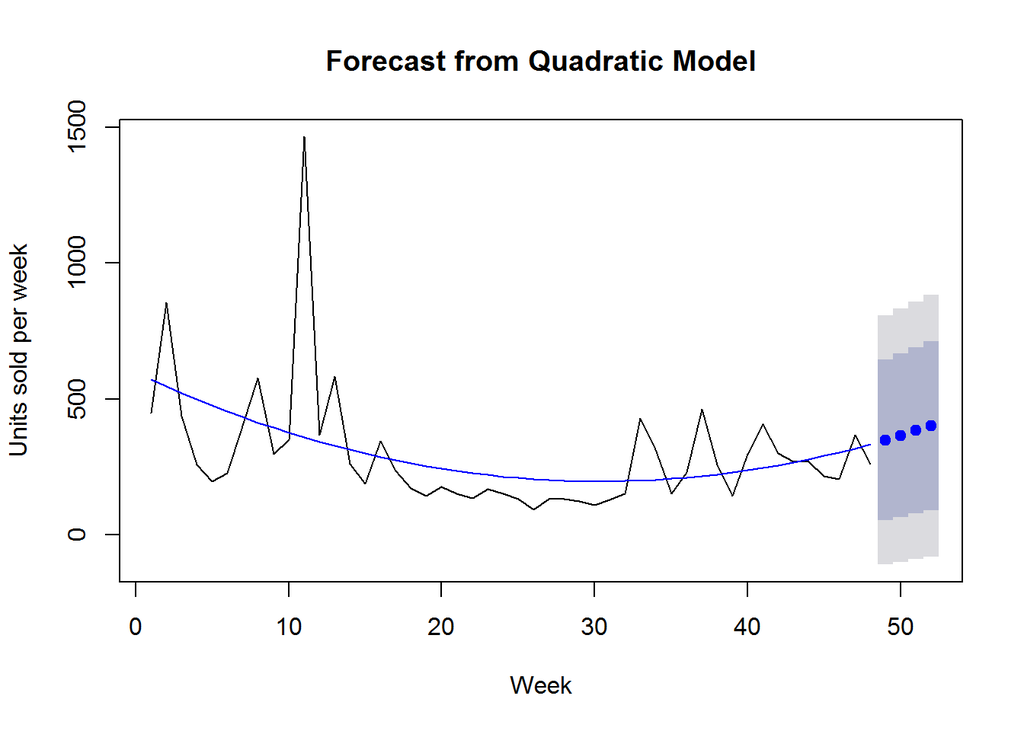

```r
soup.fit4 <- tslm(souptraining ~ trend + I(trend^2))
f4 <- forecast(soup.fit4, h = 4, level = c(80, 95))
plot(f4, ylab = "Units sold per week", xlab = "Week", main = "Forecast from Quadratic Model")
lines(fitted(soup.fit4), col = "blue")
```

```r
accuracy(f4)
```

```
##                        ME     RMSE      MAE       MPE     MAPE      MASE
## Training set 4.143532e-15 200.7228 119.5233 -23.74664 42.82662 0.7833769
##                    ACF1
## Training set 0.09213691
```

Looking from actual vs predicted plot we can say that this model is fitting our series in a much better way. Also it gave us RMSE of **200.72** and MAPE **42.82%** which is much better than former linear model , we further analyse the residuals of this model.

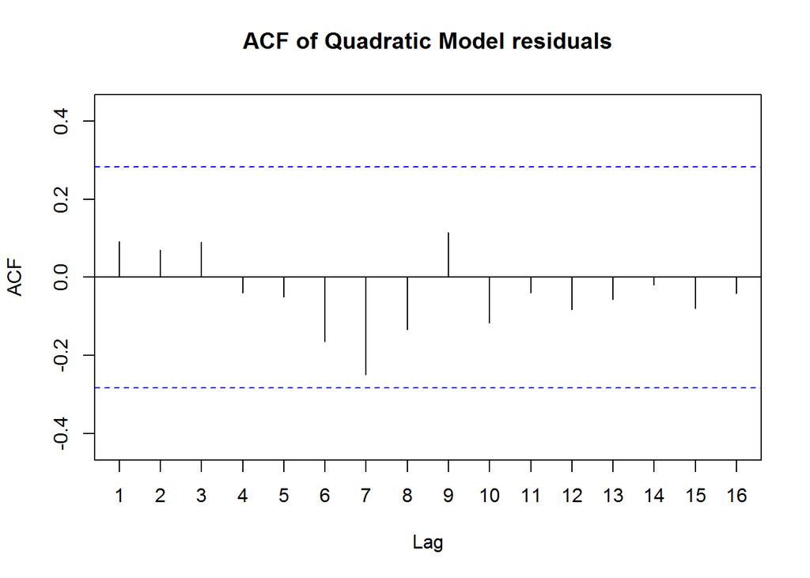

```r
res4 <- residuals(soup.fit4)
# plot(res4, main='Residuals from Quadratic Model', ylab='residuals',
# xlab='Week') abline(0,0,col='gray60')
Acf(res4, main = "ACF of Quadratic Model residuals")
```

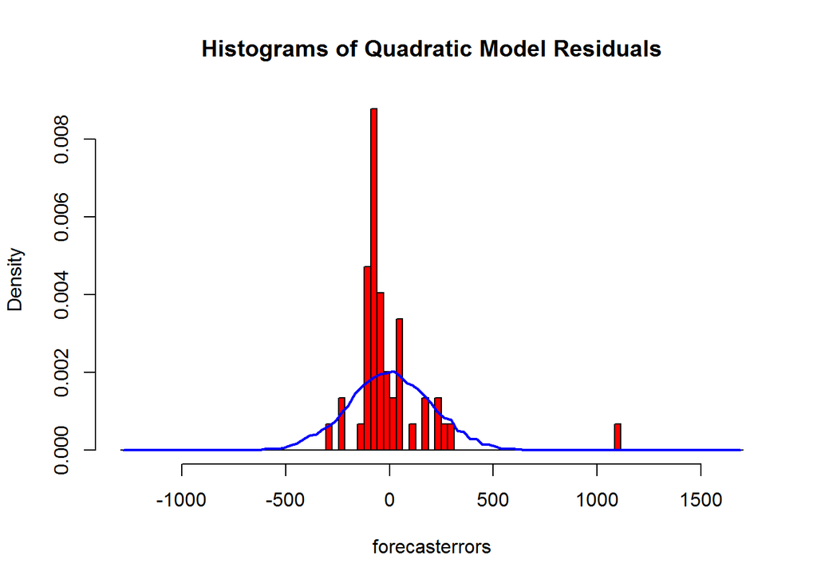

```r
plotForecastErrors(res4, "Histograms of Quadratic Model Residuals")
```

As we found that quadrtic model performed better, we tried to smoothened the series to get some clear picture about trend. We performed centered moving average and weigthed moving average smoothing and got following graphs.

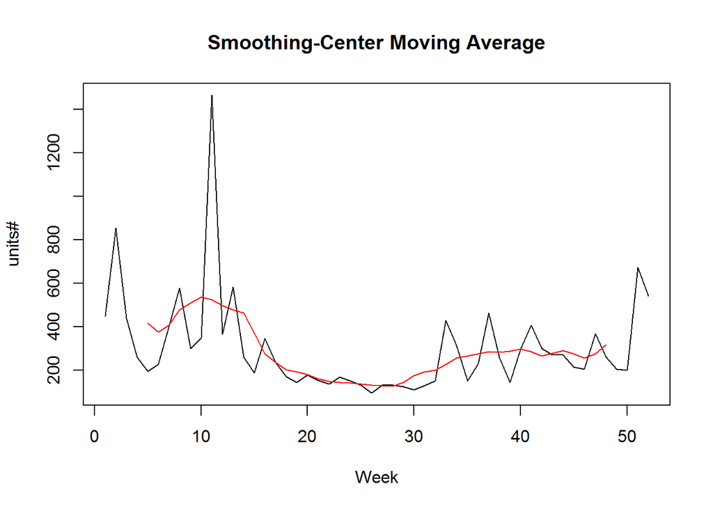

```r
plot(soupstimeseries, main = "Smoothing-Center Moving Average", ylab = "units#",
    xlab = "Week")
lines(ma(soupstimeseries, 8), col = "red")
```

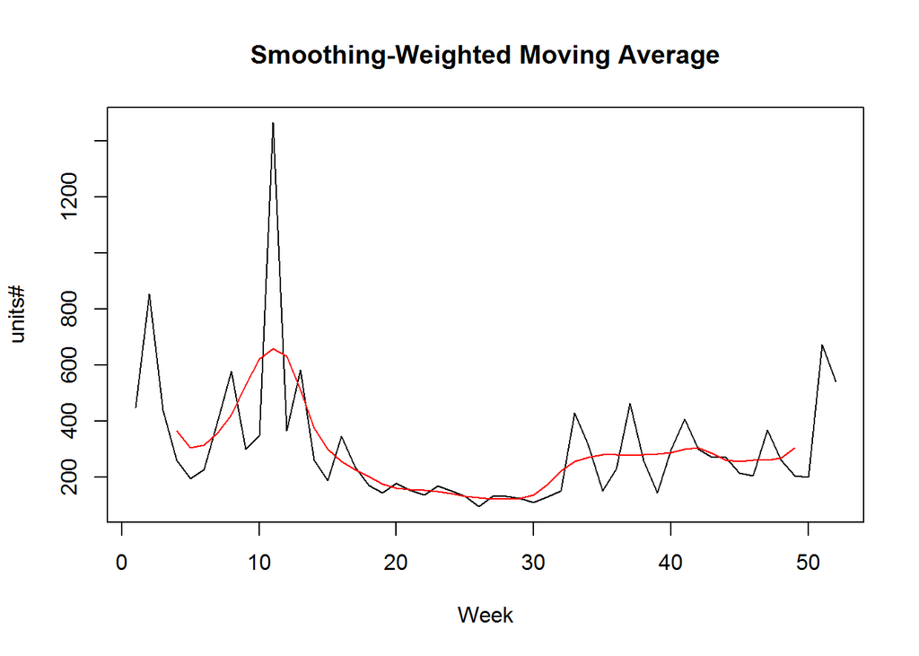

```r
plot(soupstimeseries, main = "Smoothing-Weighted Moving Average", ylab = "units#",
    xlab = "Week")
lines(ma(ma(soupstimeseries, 4), 2), col = "red")
```

From both the graphs we can say that somewhat quadtratic trend is present in series (*in red*).

Before concluding quadtratic model as best for our series we tried running few data driven model as well.

### Data driven models:

3. **Simple Exponential Method**

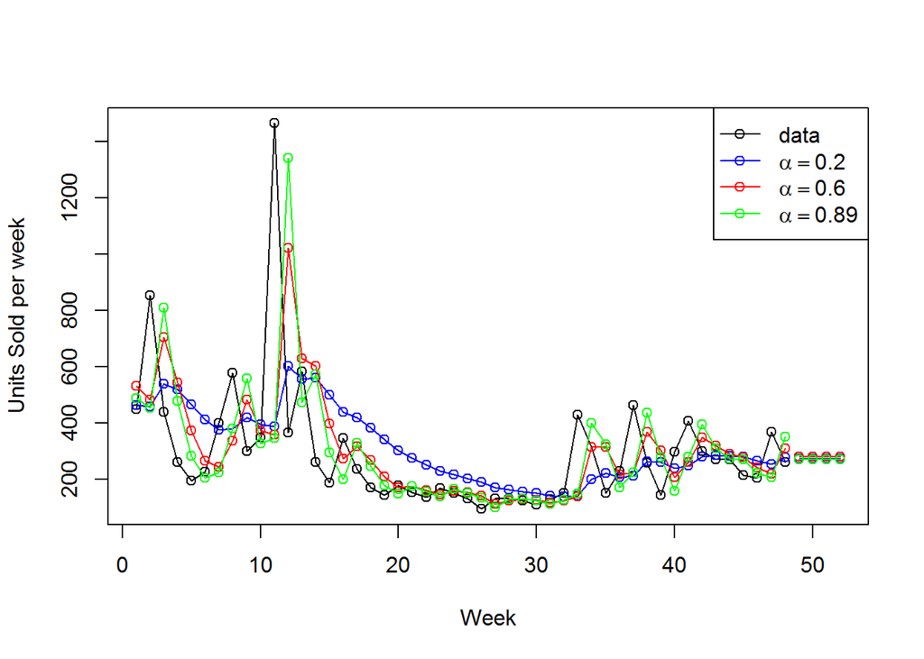

We ran SES model with different values of constant **alpha** and as it can be seen that blue line is fitting the trend better relative to others, same can be seen from below accuracy measures:

```r
print("Alpha = 0.2")
```

```
## [1] "Alpha = 0.2"
```

```r
accuracy(fit5)
```

```
##                     ME     RMSE      MAE       MPE    MAPE      MASE
## Training set -19.58065 215.3891 134.5635 -30.63449 48.7687 0.8819527
##                    ACF1
## Training set 0.03736915
```

```r
print("Alpha = 0.6")
```

```
## [1] "Alpha = 0.6"
```

```r
accuracy(fit6)
```

```
##                     ME     RMSE      MAE       MPE     MAPE      MASE
## Training set -8.740425 230.9899 132.6848 -18.76941 40.37949 0.8696393
##                    ACF1
## Training set -0.2585729
```

```r
print("Alpha = 0.89")
```

```
## [1] "Alpha = 0.89"
```

```r
accuracy(fit7)
```

```
##                     ME     RMSE      MAE       MPE     MAPE      MASE
## Training set -5.081572 256.7288 144.0958 -15.78541 42.23064 0.9444296
##                    ACF1
## Training set -0.4173463
```

Since we got insight that previous time period values are not playing important role for forecasting current period values as model with **0.2 alpha** gave least RMSE than others. We tried running holt and holt’s winter model also to see we can get better RMSE or MAPE.

4. **Holt’s Method**

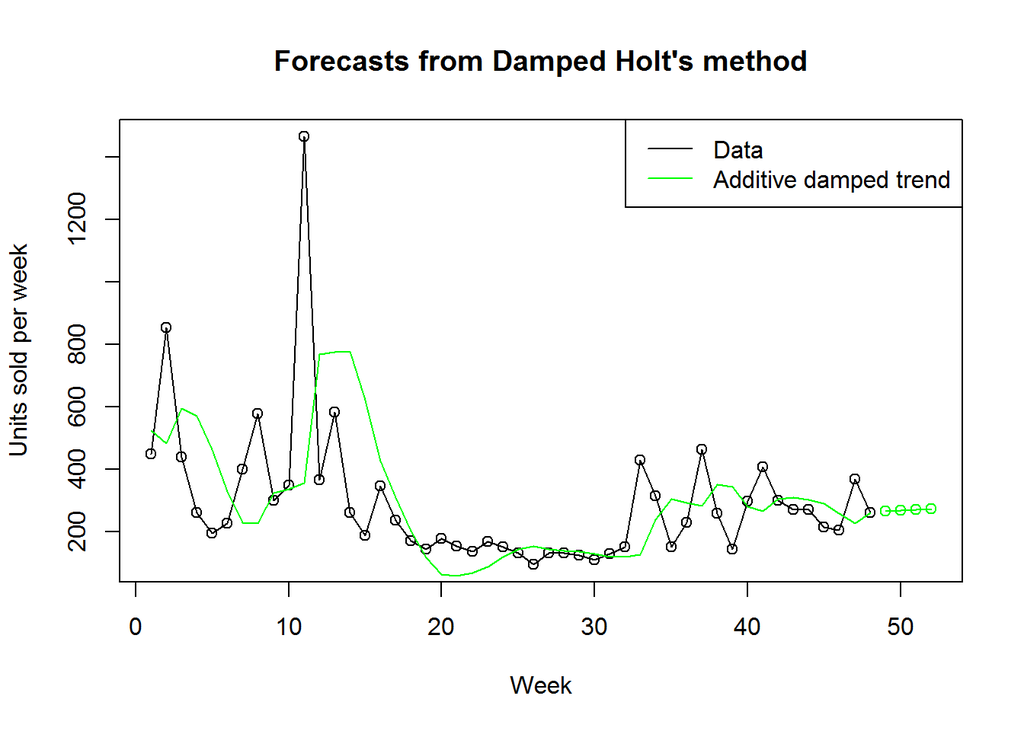

We ran damped trend holt’s model, from above graph it can be seen that it is quite close in capturing the trend of the series, we then looked to accuracy measures also

```r
accuracy(fit8)
```

```
##                     ME     RMSE      MAE      MPE     MAPE      MASE
## Training set -3.567413 236.6886 142.4227 -16.2496 46.72168 0.9334637
##                    ACF1
## Training set 0.06179321
```

5. **Holt’s Winter Method**

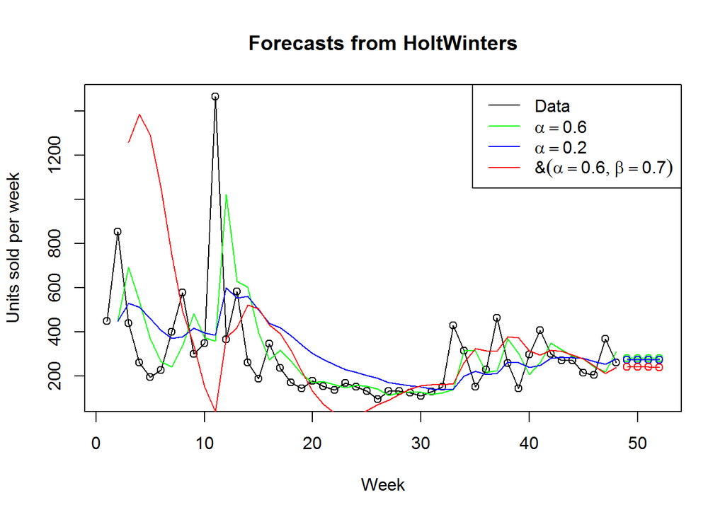

We ran holt’s winter method with different alpha & beta values keeping gamma as *FALSE* as there is no seasonality in the series and it can be seen from above graph that model with 0.2 alpha & no constant for trend smoothing is better than others. Same is reflected from below measures.

```r
print("alpha=0.6,beta=FALSE,gamma=FALSE")
```

```
## [1] "alpha=0.6,beta=FALSE,gamma=FALSE"
```

```r
accuracy(fit9_1)
```

```
##                     ME     RMSE      MAE      MPE     MAPE      MASE
## Training set -5.962224 233.8135 133.9872 6.376485 42.32257 0.8725104
##                    ACF1
## Training set -0.2499125
```

```r
print("alpha=0.2,beta=FALSE,gamma=FALSE")
```

```
## [1] "alpha=0.2,beta=FALSE,gamma=FALSE"
```

```r
accuracy(fit10_1)
```

```
##                     ME     RMSE      MAE       MPE     MAPE      MASE
## Training set -18.56606 217.6929 136.8263 -10.96713 52.36243 0.8909981
##                    ACF1
## Training set 0.03509347
```

```r
print("alpha=0.2,beta=0.7,gamma=FALSE")
```

```
## [1] "alpha=0.2,beta=0.7,gamma=FALSE"
```

```r
accuracy(fit11_1)
```

```
##                     ME     RMSE      MAE       MPE     MAPE     MASE
## Training set -63.01478 378.6924 207.4483 -4.217708 70.09834 1.352923
##                   ACF1
## Training set 0.5676059
```

#### **At the end we tried fitting all these models on our validation set and got following results:**

```
## [1] "Accuracy of quadratic regression model"
```

```
##                        ME     RMSE   MAE       MPE     MAPE      MASE
## Training set 7.105427e-15 121.1949 108.4 -10.15169 35.49831 0.5331148
##               ACF1
## Training set -0.75
```

```
## [1] "Accuracy of simpel exponential model with alpha=0.2"
```

```
##                    ME     RMSE      MAE       MPE     MAPE     MASE
## Training set 42.71519 225.8222 209.5259 -21.17863 61.32908 1.030455
##                    ACF1
## Training set 0.08742353
```

```
## [1] "Accuracy of holt's winter exponential model with alpha=0.2 and no beta gamma"
```

```
##                    ME     RMSE      MAE      MPE     MAPE     MASE
## Training set 237.1467 306.3317 239.8133 89.91198 91.21917 1.003403
##                    ACF1
## Training set -0.4839808
```

It is clear from above results that quadtratic regression model fits best to this series with least **RMSE of 121.1** and **35.4% of MAPE**. Hence we forecasted next four weeks units to be sold by using quadtratic regression model as follows.

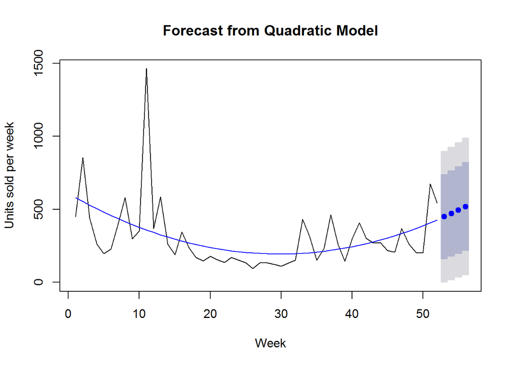

```r
soup.fitfinal <- tslm(soupstimeseries ~ trend + I(trend^2))
ffinal <- forecast(soup.fitfinal, h = 4, level = c(80, 95))
plot(ffinal, ylab = "Units sold per week", xlab = "Week", main = "Forecast from Quadratic Model")
lines(fitted(soup.fitfinal), col = "blue")
```

```r
print("Forecasted Values")
```

```
## [1] "Forecasted Values"
```

#### Forecasted Values

```
##    Point Forecast    Lo 80    Hi 80     Lo 95    Hi 95
## 53       448.2686 156.4690 740.0681 -3.126502 899.6636
## 54       470.5964 175.0807 766.1120 13.452851 927.7399
## 55       493.8627 194.1923 793.5331 30.291963 957.4334
## 56       518.0675 213.7839 822.3511 47.360522 988.7745
```